# mgraph.R - mini graph module

Detlef Groth, University of Potsdam

2022-05-09

bkcd - chords - mgraph - sbi

Module Vignette: mgraph vignette

## R functions for working with graphs - 2022-05-09

This is a collection of useful functions shown in my teachings in the course Statistical Bioinformatics, Practical Bioinformatics, Machine Learning in Bioinformatics and for the course Databases and Practical Programming which deal with graph like data. Below you find the documentation for the following functions  
and variables:

Functions:

- mgraph$new - create a new graph based on an adjacency matrix or list or some standard graph types
- mgraph$autonames - create names for nodes and other data structures
- mgraph$components - extract graph components
- mgraph$connect - connect graph components
- mgraph$d2u - create an undirected graph out of a directed graph
- mgraph$data2graph - create graph out of a data using different algorithms
- mgraph$degree - number of undirected or incoming and outgoing edges
- mgraph$graph2data - correlation data for the given graph
- mgraph$kroki - visualize diagram code for ditaa, graphviz etc
- mgraph$layout - calculate a two dimensional graph layout
- mgraph$nodeColors - node colors for directed graphs
- mgraph$plot - plot a mgraph object (S3 - plot.mgraph)
- mgraph$shortest.paths - calculate the shortest path for a given graph
- mgraph$summary - provide basic information about a mgraph object (S3 - summary.mgraph)
- mgraph$u2d - create an directed graph out of an undirected graph

Variables:

The variables are considered readonly.

- FILENAME - the actual filename of the script and the path to it, can be used to source files other files with relative paths
- VERSION - the last change date of the file

## Usage

To use the functions just source the file mgraph.R into your R application:

```r
# notrun
source("mgraph.R")
```

All function of this file are added to an environment variable called *mgraph*.  
To have a look which variables and functions exists in this namesspace you can use the function call `ls(mgraph)`. Only function starting with lowercase letters should be used in your scripts:

```r
ls(mgraph,pattern="^[a-z]")
```

```
##  [1] "autonames"      "components"     "connect"        "d2u"
##  [5] "data2graph"     "degree"         "graph2data"     "kroki"
##  [9] "layout"         "new"            "nodeColors"     "plot"
## [13] "shortest.paths" "summary"        "u2d"
```

## Functions

**mgraph$new(x)**

> Create an new graph object based on either an adjacency matrix or an adjacency list.

> This function …

> Arguments:
> - *x* - either a adjacency matrix or an adjacency list, if not given a type must be given
> - *type* - a graph type, one of ‘angie’, ‘band’, ‘barabasi’, ‘circle’, ‘cluster’, ‘hubs’, ‘random’, ‘regular’ or ‘werner’, default: ‘random’
> - *nodes* - number of nodes for a given type, default: 10
> - *number* of edges for a given type, not used for type “barabasi”, default: 12
> - *m* - number of edges added in each iteration of type is ‘barabasi’, default: 1
> - *k* - the degree for a regular graph, or the number of clusters for a cluster graph or the number of hubs for a hubs graph, default: 2

> Examples:

> ```r
>   M <- matrix(0,nrow=7,ncol=7)
>   rownames(M)=colnames(M)=LETTERS[1:7]
>   M[c('A','B'),'C']=1
>   M['C','D']=1
>   M['D',c('E','F')]=1
>   M['E','F']=1
>   G=mgraph$new(M)
>   set.seed(125)
>   R = mgraph$new(type="random",nodes=8,edges=9)
>   summary(R)
> ```

> ```
> ##      nodes      edges   directed components
> ##          8          9          1          2
> ```

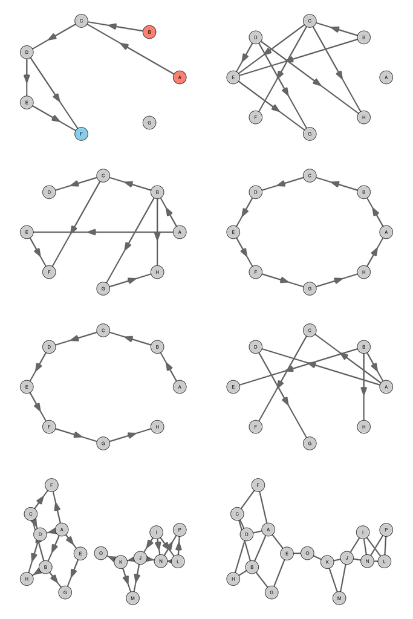

> ```r
>   A = mgraph$new(type="angie",nodes=8,edges=9)
>   C = mgraph$new(type="circle",nodes=8)
>   B = mgraph$new(type="band",nodes=8)
>   par(mfrow=c(4,2),mai=rep(0.1,4))
>   plot(G,layout="circle",vertex.color=mgraph$nodeColors(G))
>   plot(R,layout="circle")
>   plot(A,layout="circle")
>   plot(C,layout="circle")
>   plot(B,layout="circle")
>   plot(mgraph$new(type="bara",nodes=8,m=1),layout="circle")
>   CLa=mgraph$new(type="cluster",nodes=16,edges=22,k=2)
>   CLb=mgraph$connect(CLa)
>   lay=mgraph$layout(CLb)
>   plot(CLa,layout=lay);plot(CLb,layout=lay)
> ```

**mgraph$autonames(prefix,n)**

> Create names for nodes and other data structures.

> This function aids in creating standard node labels for graphs.

> Arguments:
> - *prefix* - one or more prefixes to be used.
> - *n* - how many labels

> Examples:

> ```r
>   mgraph$autonames(12)
> ```

> ```
> ##  [1] "A" "B" "C" "D" "E" "F" "G" "H" "I" "J" "K" "L"
> ```

> ```r
>   mgraph$autonames(12,LETTERS[1:4])
> ```

> ```
> ##  [1] "A1" "B1" "C1" "D1" "A2" "B2" "C2" "D2" "A3" "B3" "C3" "D3"
> ```

> ```r
>   mgraph$autonames(12,"R")
> ```

> ```
> ##  [1] "R01" "R02" "R03" "R04" "R05" "R06" "R07" "R08" "R09" "R10" "R11" "R12"
> ```

> Author: Masiar Novine

**mgraph$components(g)**

> Return graph components, nodes which are connected are within the same component.

> This function …

> Arguments:
> - *g* - a mgraph object or an adjacency matrix or an adjacency list

> Examples:

> ```r
>   mgraph$components(G)
> ```

> ```
> ## A B C D E F G
> ## 1 1 1 1 1 1 2
> ```

**mgraph$connect(g)**

> Return a graph which has only a single component.

> This function creates a single component graph by adding random edges between different components.

> Arguments:
> - *g* - a mgraph object or an adjacency matrix or an adjacency list

> Examples:

> ```r
>   H=mgraph$connect(G)
>   H
> ```

> ```
> ##   A B C D E F G
> ## A 0 0 1 0 0 0 1
> ## B 0 0 1 0 0 0 0
> ## C 1 1 0 1 0 0 0
> ## D 0 0 1 0 1 1 0
> ## E 0 0 0 1 0 1 0
> ## F 0 0 0 1 1 0 0
> ## G 1 0 0 0 0 0 0
> ## attr(,"class")
> ## [1] "mgraph"
> ```

> ```r
>   mgraph$components(H)
> ```

> ```
> ## A B C D E F G
> ## 1 1 1 1 1 1 1
> ```

**mgraph$d2u(g)**

> Create an undirected graph out of a directed graph with the same number of edges.

> This function gets an directed graph and convertes all edges from directed ones to undirected ones. The number of edges should stay the same, the edge sign (+ or -) stays the same.

> Arguments:
> - *g* - a mgraph object or an adjacency matrix

> Examples:

> ```r
>   par(mfrow=c(1,2),mai=rep(0.2,4))
>   A=mgraph$new(type="angie",nodes=4,edges=4)
>   A
> ```

> ```
> ##   A B C D
> ## A 0 1 1 1
> ## B 0 0 0 1
> ## C 0 0 0 0
> ## D 0 0 0 0
> ## attr(,"class")
> ## [1] "mgraph"
> ```

> ```r
>   U=mgraph$d2u(A)
>   U
> ```

> ```
> ##   A B C D
> ## A 0 1 1 1
> ## B 1 0 0 1
> ## C 1 0 0 0
> ## D 1 1 0 0
> ## attr(,"class")
> ## [1] "mgraph"
> ```

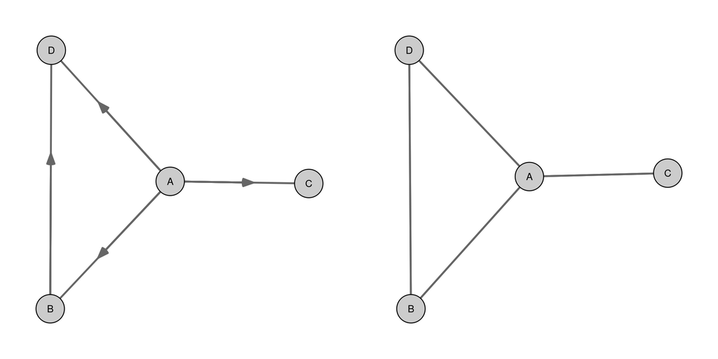

> ```r
>   plot(A); plot(U)
> ```

**mgraph$data2graph(x,type=“rpart”)**

> Create graph out of a data using different algorithms.

> This function gets some input data and creates an un- or a directed graph based on the structure of the input data.

> Examples:

> ```r
>   par(mfrow=c(3,2),mai=c(0.2,0.2,0.8,0.1))
>   A=mgraph$new(type="angie",nodes=8,edges=8)
>   data=mgraph$graph2data(A,prop=0.02,iter=50)
>   round(cor(t(data),method="spearman"),2)
> ```

> ```
> ##      A     B    C    D    E     F    G     H
> ## A 1.00  0.44 0.57 0.19 0.31  0.08 0.17  0.04
> ## B 0.44  1.00 0.26 0.01 0.11 -0.01 0.40 -0.01
> ## C 0.57  0.26 1.00 0.35 0.39  0.09 0.16  0.06
> ## D 0.19  0.01 0.35 1.00 0.13  0.19 0.14  0.11
> ## E 0.31  0.11 0.39 0.13 1.00  0.29 0.16  0.13
> ## F 0.08 -0.01 0.09 0.19 0.29  1.00 0.36  0.16
> ## G 0.17  0.40 0.16 0.14 0.16  0.36 1.00  0.18
> ## H 0.04 -0.01 0.06 0.11 0.13  0.16 0.18  1.00
> ```

> ```r
>   B=mgraph$data2graph(t(data),type="rpart",rs=0.05)
> ```

> ```r
>   C=mgraph$data2graph(t(data),type="pearson",rs=0.05)
>   D=mgraph$data2graph(t(data),type="kendall",rs=0.1)
>   E=mgraph$data2graph(t(data),type="lm",rs=0.05)
>   F=mgraph$data2graph(t(data),type="lm",rs=0.01)
>   round(B$rs,2)
> ```

> ```
> ##      A    B    C D    E    F    G    H
> ## A 0.00 0.00 0.51 0 0.00 0.00 0.00 0.00
> ## B 0.34 0.00 0.00 0 0.00 0.00 0.00 0.00
> ## C 0.49 0.00 0.00 0 0.00 0.00 0.06 0.00
> ## D 0.00 0.00 0.27 0 0.00 0.00 0.00 0.00
> ## E 0.00 0.00 0.30 0 0.00 0.06 0.00 0.00
> ## F 0.00 0.07 0.00 0 0.05 0.00 0.27 0.00
> ## G 0.00 0.25 0.00 0 0.00 0.13 0.00 0.09
> ## H 0.00 0.10 0.00 0 0.00 0.00 0.13 0.00
> ```

> ```r
>   B$graph
> ```

> ```
> ##   A B C D E F G H
> ## A 0 1 1 0 0 0 0 0
> ## B 1 0 0 0 0 0 1 0
> ## C 1 0 0 1 1 0 1 0
> ## D 0 0 1 0 0 0 0 0
> ## E 0 0 1 0 0 1 0 0
> ## F 0 0 0 0 1 0 1 0
> ## G 0 1 1 0 0 1 0 1
> ## H 0 0 0 0 0 0 1 0
> ## attr(,"class")
> ## [1] "mgraph"
> ```

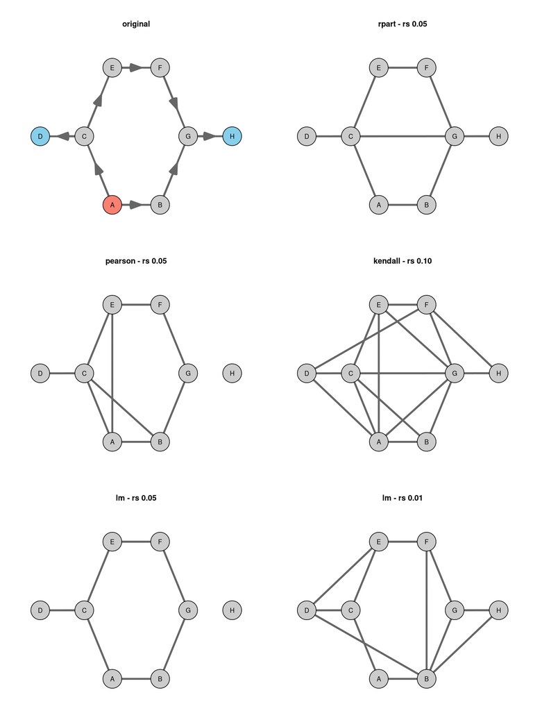

> ```r
>   lay=mgraph$layout(A)
>   plot(A,layout=lay,main="original",vertex.color=mgraph$nodeColors(A));
>   plot(B$graph,layout=lay,main="rpart - rs 0.05")
>   plot(C$graph,layout=lay,main="pearson - rs 0.05")
>   plot(D$graph,layout=lay,main="kendall - rs 0.10")
>   plot(E$graph,layout=lay,main="lm - rs 0.05")
>   plot(F$graph,layout=lay,main="lm - rs 0.01")
> ```

**mgraph$degree(g,mode=“undirected”)**

> Return the number of undirected or incoming and outgoing edges.

> This function returns the …

> Arguments:
> - *g* - a mgraph object or an adjacency matrix

> Examples:

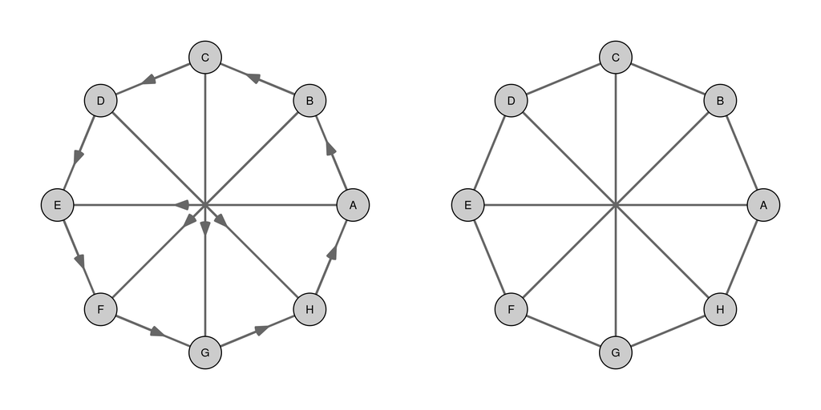

> ```r
>   par(mfrow=c(1,2),mai=rep(0.2,4))
>   A=mgraph$new(type="regular",nodes=8,k=3)
>   plot(A,layout="circle"); plot(mgraph$d2u(A),layout="circle");
> ```

> ```r
>   mgraph$degree(A)
> ```

> ```
> ## A B C D E F G H
> ## 3 3 3 3 3 3 3 3
> ```

> ```r
>   mgraph$degree(A,mode="out")
> ```

> ```
> ## A B C D E F G H
> ## 2 2 2 2 1 1 1 1
> ```

> ```r
>   mgraph$degree(A,mode="in")
> ```

> ```
> ## A B C D E F G H
> ## 1 1 1 1 2 2 2 2
> ```

**mgraph$graph2data(g,n=100)**

> Create correlation data for the given graph.

> This function is a short implementation of the algorithm in Novine et. al. 2022.

> Arguments:
> - *g* - a mgraph object or an adjacency matrix
> - *n* - the number of measurements per node, default: 100
> - *iter* - the number of iterations, default: 15
> - *sd* - initial standard deviation, default: 2
> - *val* - initial node value, default: 100
> - *prop* - proportion of the target node value take from the source node, default: 0.05
> - *noise* - the sd for the noise value added after each iteration using rnorm function with mean 0, default: 1

> Examples:

> ```r
>   par(mfrow=c(1,2),mai=rep(0.2,4))
>   A=mgraph$new(type="angie",nodes=8,edges=10)
>   plot(A,layout="circle");
>   C=mgraph$graph2data(A,prop=0.05)
>   round(cor(t(C)),2)
> ```

> ```
> ##      A    B    C    D    E    F    G    H
> ## A 1.00 0.35 0.27 0.54 0.13 0.44 0.12 0.39
> ## B 0.35 1.00 0.21 0.19 0.08 0.19 0.05 0.11
> ## C 0.27 0.21 1.00 0.33 0.44 0.37 0.03 0.11
> ## D 0.54 0.19 0.33 1.00 0.35 0.33 0.18 0.17
> ## E 0.13 0.08 0.44 0.35 1.00 0.20 0.24 0.15
> ## F 0.44 0.19 0.37 0.33 0.20 1.00 0.24 0.34
> ## G 0.12 0.05 0.03 0.18 0.24 0.24 1.00 0.10
> ## H 0.39 0.11 0.11 0.17 0.15 0.34 0.10 1.00
> ```

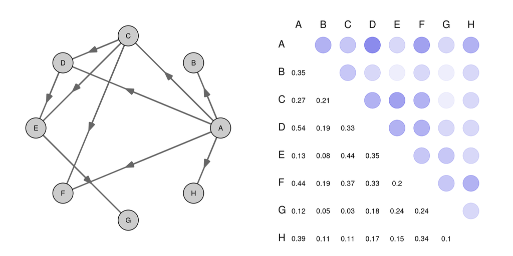

> ```r
>   sbi$corrplot(cor(t(C)))
> ```

**mgraph$kroki(text,type=“ditaa”,ext=“png”)**

> Attention, often does not work! Create diagram URL’s based on kroki supported tools.

> This function is creates a URL which can be easily embedded into Markdown code for displaying diagrams supported by the online tool kroki.io. There is as well an online diagram editor, see here [niolesk](https://niolesk.top/).

> Arguments:
> - *text* - some diagram code, default: “A –> B”
> - *filename* - some input file, either *text* or *file* must be given, default: NULL
> - *mode* - diagram type, supported is ditaa, graphviz, and many others, see the kroki website, default: ditaa
> - *ext* - file extension, usally ‘png’, ‘svg’ or ‘pdf’, default: ‘png’

> Examples:

> ```r
>   url1=mgraph$kroki("
>   digraph g {
>      rankdir=\"LR\";
>      node[style=filled,fillcolor=salmon];
>      A -> B -> C ;
>   }",
>   type="graphviz")
>   substr(url1,1,40)
> ```

> ```
> ## [1] "https://kroki.io/graphviz/png/eJxT4FJQSM"
> ```

> ```r
>   url2=mgraph$kroki("
>   +---------+    +--------+
>   |    AcEEF+--->+   BcFEE+
>   +---------+    +--------+
>   ")
> ```

> To embed the image you can use Markdown code like here:

> ```
> # remove space before r letter
> ![ ](` r url1 `)
> ```

> Here the output:

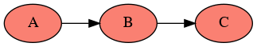

> And here the image for the second diagram, a Ditaa diagram:

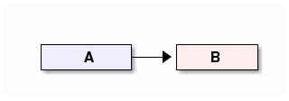

> The diagram code can be read as well from a file here a Ditaa file:

> ```r
>   cat(sbi$file.head("hw.ditaa"),sep="\n")
> ```

> ```
> ## /---------\  +--------+   +--------+
> ## |  cFDD   |  |        |   | {s}    |
> ## |  Hello  +->| World! +-->|   DB   |
> ## |         |  | cDDF   |   |  cFFD  |
> ## \---------/  +--------+   +--------+
> ##
> ```

> ```
> ## [1] 155
> ```

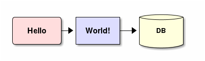

> ```r
>   url3=mgraph$kroki(filename="hw.ditaa")
>   nchar(url3)
> ```

**mgraph$layout(g,mode=“sam”)**

> Return a layout for a given graph, ready for plotting.

> This function …

> Arguments:
> - *g* - a mgraph object or an adjacency matrix or an adjacency list
> - *mode* - either ‘mds’,‘sam’, ‘circle’, ‘star’ …

> Examples:

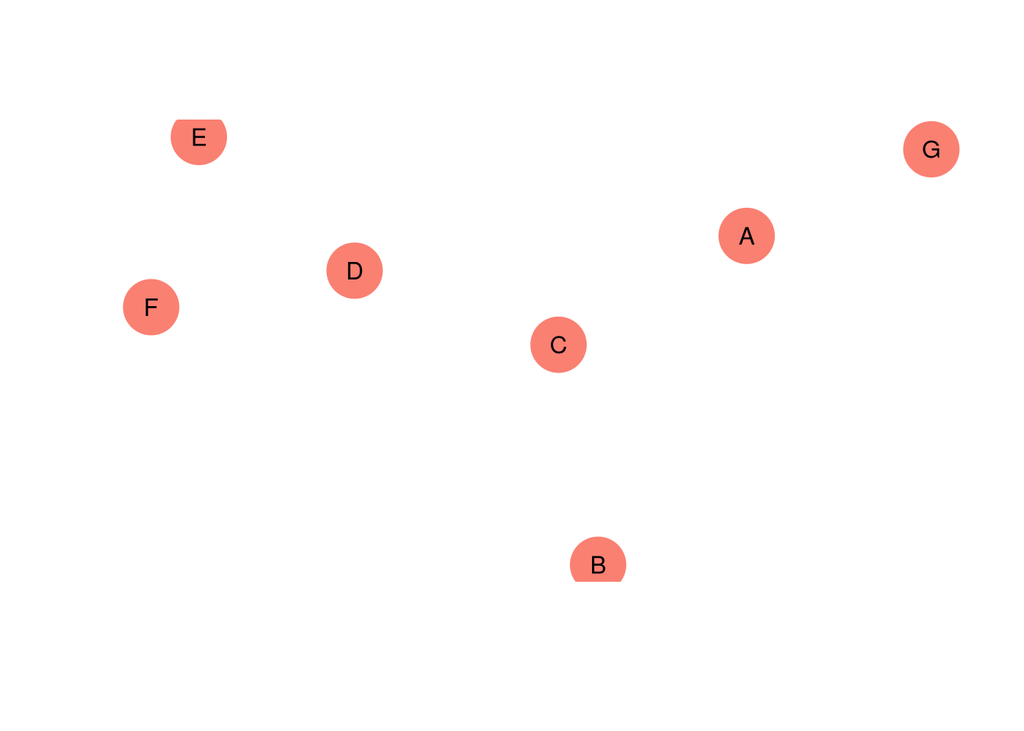

> ```r
>   lay=mgraph$layout(G)
>   plot(lay, pch=19,col="salmon",cex=5,xlab="",ylab="",axes=FALSE)
>   text(lay,rownames(G))
> ```

**mgraph$nodeColors(g,colors=c(“skyblue”,“grey80”,“salmon”)**

> Returns node colors for directed graphs.

> This function simplifies automatic color coding of nodes for directed graphs. Nodes will be colored based on their degree properties, based on their incoming and outcoming edges.

> Arguments:
> - *g* - a mgraph object or an adjacency matrix or an adjacency list
> - *col* - default colors for nodes with only incoming, in- and outgoing and only outgoing edges, default: c(“skyblue”,“grey80”,“salmon”)

> Examples:

> ```r
>   par(mfrow=c(1,2),mai=rep(0.1,4))
>   A=mgraph$new(type="random",nodes=6,edges=8)
>   cols=mgraph$nodeColors(A)
>   mgraph$degree(A,mode="in")
> ```

> ```
> ## A B C D E F
> ## 0 1 1 2 3 1
> ```

> ```r
>   mgraph$degree(A,mode="out")
> ```

> ```
> ## A B C D E F
> ## 2 3 2 1 0 0
> ```

> ```r
>   cols
> ```

> ```
> ## [1] "salmon"  "grey80"  "grey80"  "grey80"  "skyblue" "skyblue"
> ```

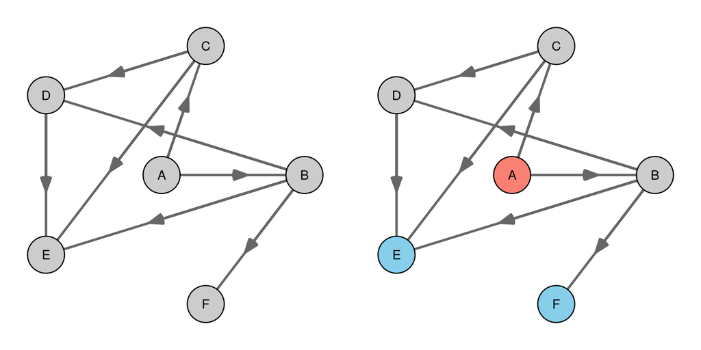

> ```r
>   plot(A, layout="star")
>   plot(A, layout="star",vertex.color=cols)
> ```

**mgraph$plot(g,layout=“sam”)**

> Plot a given graph or adjacency matrix.

> This function … is as well an S3 function for mgraph objects

> Arguments:
> - *g* - a mgraph object or an adjacency matrix or an adjacency list
> - *layout* - either ‘mds’,‘sam’, ‘circle’, ‘star’ or an two column matrix or data frame with x and y coordinates,default: ‘sam’
> - *vertex.size* - the size of the vertex circles, default: 1
> - *vertex.color* - the color of the vertices, default: ‘salmon’
> - *pch* - the plotting character for the vertices, default: 19

> Examples:

> ```r
>   par(mfrow=c(2,2),mai=rep(0.2,4))
>   mgraph$plot(G, layout="sam")
>   plot(G, layout="circle") # plot as S3 function
>   plot(R, layout="sam",vertex.color="grey90")
>   M=matrix(0,ncol=5,nrow=5)
>   diag(M)=0
>   M[upper.tri(M)]= as.integer(rlnorm(10,0.35))
>   M[lower.tri(M)]=t(M)[lower.tri(M)]
>   rownames(M)=colnames(M)=LETTERS[1:5]
>   M=mgraph$new(M)
>   M
> ```

> ```
> ##   A B C D E
> ## A 0 2 1 1 0
> ## B 2 0 3 1 4
> ## C 1 3 0 0 1
> ## D 1 1 0 0 0
> ## E 0 4 1 0 0
> ## attr(,"class")
> ## [1] "mgraph"
> ```

> ```r
>   identical(M,t(M))
> ```

> ```
> ## [1] TRUE
> ```

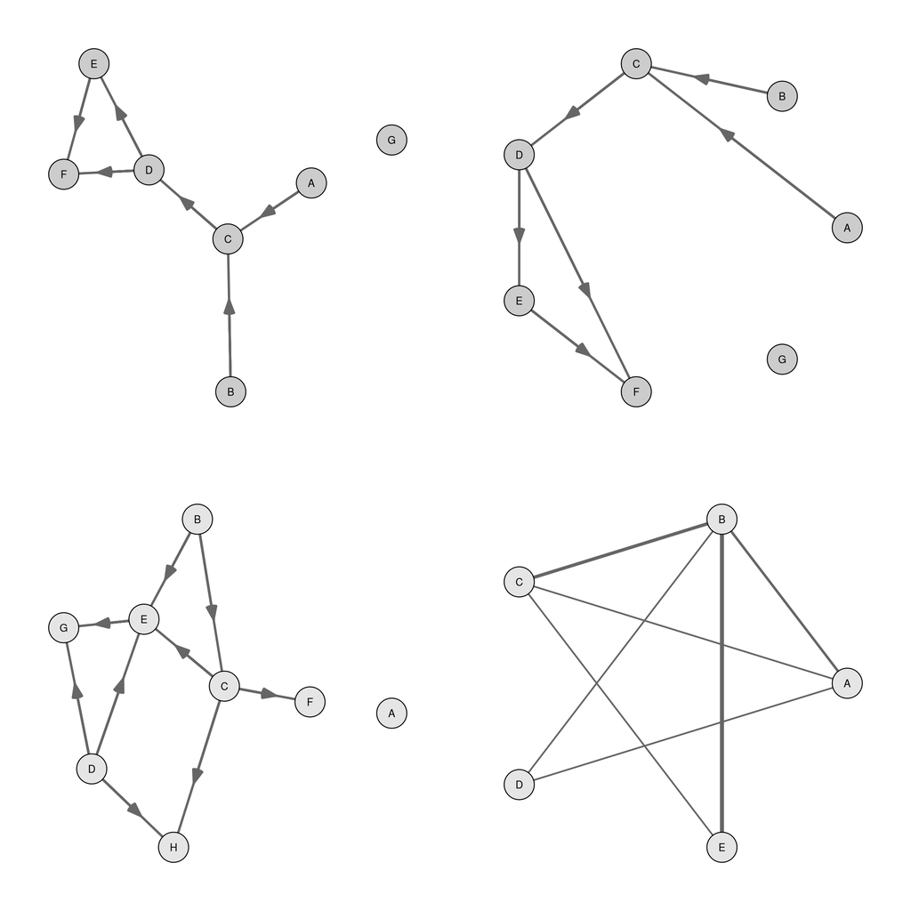

> ```r
>   plot(M, layout="circle",vertex.color="grey90",weighted=TRUE,lwd=1)
> ```

**mgraph$shortest.path(g)**

> Calculate the shortest paths between all graph nodes.

> This function …

> Arguments:
> - *g* - a mgraph object created with *mgraph$new*.

> Returns: a matrix with the shortest paths

> Examples:

> ```r
>   G
> ```

> ```
> ##   A B C D E F G
> ## A 0 0 1 0 0 0 0
> ## B 0 0 1 0 0 0 0
> ## C 0 0 0 1 0 0 0
> ## D 0 0 0 0 1 1 0
> ## E 0 0 0 0 0 1 0
> ## F 0 0 0 0 0 0 0
> ## G 0 0 0 0 0 0 0
> ## attr(,"class")
> ## [1] "mgraph"
> ```

> ```r
>   mgraph$shortest.paths(G)
> ```

> ```
> ##     A   B   C   D   E   F   G
> ## A   0 Inf   1   2   3   3 Inf
> ## B Inf   0   1   2   3   3 Inf
> ## C Inf Inf   0   1   2   2 Inf
> ## D Inf Inf Inf   0   1   1 Inf
> ## E Inf Inf Inf Inf   0   1 Inf
> ## F Inf Inf Inf Inf Inf   0 Inf
> ## G Inf Inf Inf Inf Inf Inf   0
> ## attr(,"class")
> ## [1] "mgraph"
> ```

> ```r
>   mgraph$shortest.paths(G,mode="undirected")
> ```

> ```
> ##     A   B   C   D   E   F   G
> ## A   0   2   1   2   3   3 Inf
> ## B   2   0   1   2   3   3 Inf
> ## C   1   1   0   1   2   2 Inf
> ## D   2   2   1   0   1   1 Inf
> ## E   3   3   2   1   0   1 Inf
> ## F   3   3   2   1   1   0 Inf
> ## G Inf Inf Inf Inf Inf Inf   0
> ## attr(,"class")
> ## [1] "mgraph"
> ```

**mgraph$summary(g)**

> Returns basic graph information.

> This function returns basic graph informations about the number of nodes and edges, if it is a directed graph or not and if there are existing several unconnected components. This function is as well S3 function `summary.mgraph`.

> Arguments:
> - *g* - a mgraph object created with *mgraph$new*.

> Returns: a list object with components:
> - *nodes* - number of nodes
> - *edges* - number of edges
> - *directed* - boolean if graph is directed
> - *components* - the number of graph components, unconnected subgraphs

> Examples:

> ```r
>   mgraph$summary(G)
> ```

> ```
> ##      nodes      edges   directed components
> ##          7          6          1          2
> ```

> ```r
>   summary(H) # as S3 method
> ```

> ```
> ##      nodes      edges   directed components
> ##          7          7          0          1
> ```

> ```r
>   names(summary(H))
> ```

> ```
> ## [1] "nodes"      "edges"      "directed"   "components"
> ```

**mgraph$u2d(g)**

> Create an directed graph out of an undirected graph.

> This function creates a direcred graph based on an undirected graph.

> Arguments:
> - *g* - a mgraph object created with *mgraph$new*.
> - *shuffle* - should the edge directions been shuffled, if FALSE every time the same graph will be created, default: FALSE

> Returns: a mgraph object

> Examples:

> ```r
>   par(mfrow=c(2,2),mai=rep(0.1,4))
>   G=mgraph$new(type="angie",nodes=7,edges=9)
>   U=mgraph$d2u(G)
>   H=mgraph$u2d(U)
>   identical(G,H)
> ```

> ```
> ## [1] TRUE
> ```

> ```r
>   I=mgraph$u2d(U,shuffle=TRUE)
>   identical(G,I)
> ```

> ```
> ## [1] FALSE
> ```

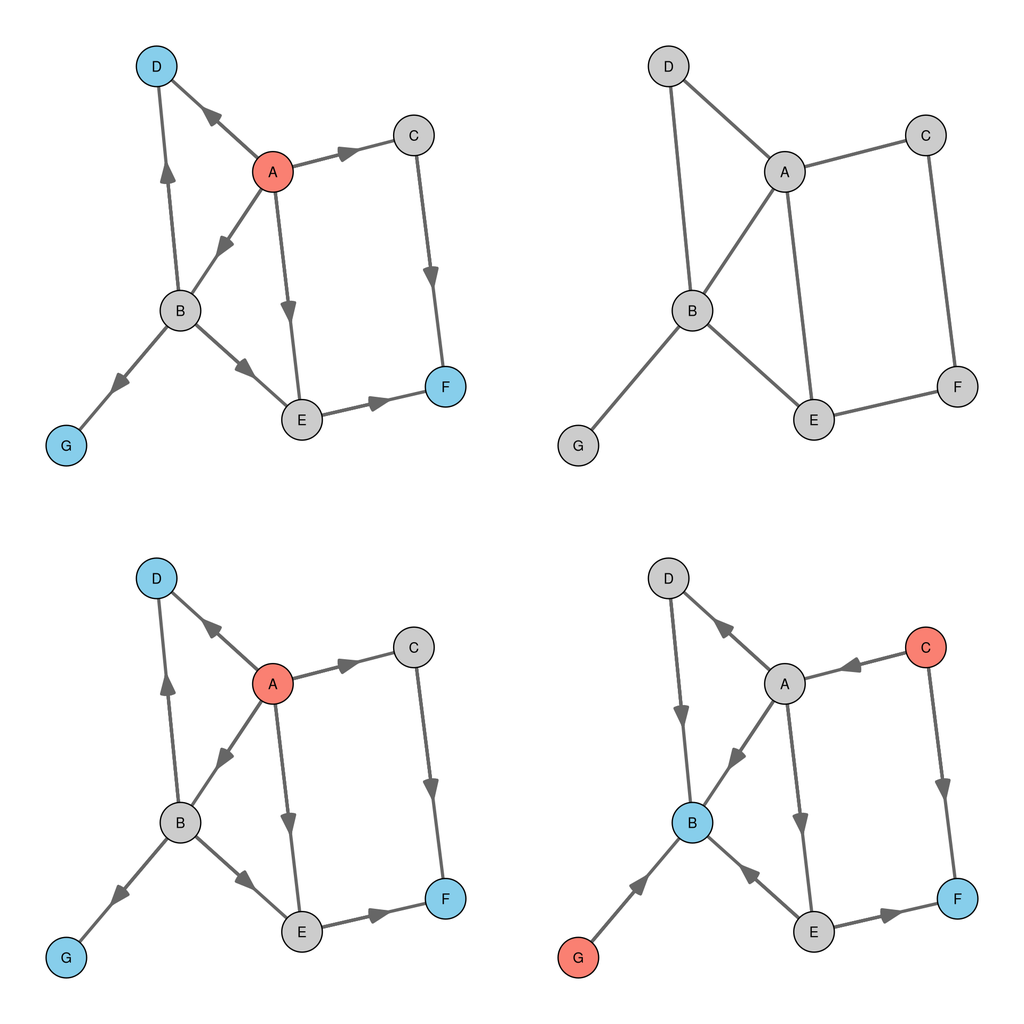

> ```r
>   lay=mgraph$layout(G)
>   plot(G,layout=lay,vertex.color=mgraph$nodeColors(G))
>   plot(U,layout=lay)
>   plot(H,layout=lay,vertex.color=mgraph$nodeColors(H))
>   plot(I,layout=lay,vertex.color=mgraph$nodeColors(I))
> ```

## Citation

How to cite this package:

```
# notrun
@Misc{Groth2022mgraph,
  author =   {Detlef Groth},
  title =    {mgraph.R - the mini graph module.},
  howpublished = {\url{https://github.com/mittelmark/Rcode}},
  year = {2022}
}
```

Groth, D. (2022). mgraph.R - the mini graph module. https://github.com/mittelmark/Rcode

## Documentation

This documentation was created directly from the file *mgraph.R* using the following commands in the terminal using the Rmarkdown package:

```
# notrun
Rscript mgraph.R --eval
```

Alternatively you can just extract the plain documentation without output of the code chunks like this:

```
# not run
Rscript mgraph.R --docu
```

## Disclaimer

This file contains a few important R functions to be used for illustration and to more easily learn from the code.  
The functions have much less error checking than function you can find in R packages available on CRAN. If you do serious statistical analysis with graphs I recommend to use those packages. Here is a list of packages I recommend very much:

- [igraph](https://cran.r-project.org/web/packages/igraph/)
- [network](https://cran.r-project.org/web/packages/network/)
- diagram
- [huge](https://cran.r-project.org/web/packages/huge/)

## ChangeLog

- 2022-05-04 - Version 0.1

## Copyright

Copyright @ 2022 - Detlef Groth, University of Potsdam

License: MIT - License